# Plots of Data Collected over Time

David Gerbing

Plot ordered data values collected over time in one of two ways that correspond to how the values are labeled.

- Run Chart: Label the data values from 1 to the number of values ordered by their time of collection.
- Time Series Chart: Label the data values by the time and/or date each data value was collected.

## Run Chart

Meaningful for sequentially ordered numerical data values such as by time, plot a run chart of a single variable according to the parameter `run`. Analogous to a time series visualization, the run chart plots the data values sequentially, but without dates or times. An analysis of the runs is also provided.

Illustrate with the **lessR** *Employee* data.

```r
d <- Read("Employee")
```

```
##
## >>> Suggestions
## Recommended binary format for data files: feather
##   Create with Write(d, "your_file", format="feather")
## More details about your data, Enter:  details()  for d, or  details(name)
##
## Data Types
## ------------------------------------------------------------
## character: Non-numeric data values
## integer: Numeric data values, integers only
## double: Numeric data values with decimal digits
## ------------------------------------------------------------
##
##     Variable                  Missing  Unique
##         Name     Type  Values  Values  Values   First and last values
## ------------------------------------------------------------------------------------------
##  1     Years   integer     36       1      16   7  NA  7 ... 1  2  10
##  2    Gender character     37       0       2   M  M  W ... W  W  M
##  3      Dept character     36       1       5   ADMN  SALE  FINC ... MKTG  SALE  FINC
##  4    Salary    double     37       0      37   53788.26  94494.58 ... 56508.32  57562.36
##  5    JobSat character     35       2       3   med  low  high ... high  low  high
##  6      Plan   integer     37       0       3   1  1  2 ... 2  2  1
##  7       Pre   integer     37       0      27   82  62  90 ... 83  59  80
##  8      Post   integer     37       0      22   92  74  86 ... 90  71  87
## ------------------------------------------------------------------------------------------
```

The data values for the variable *Salary* are not actually collected over time, but for illustration, here create a run chart of *Salary* as if the data were collected over time. The indices, the sequence of integers from 1 to the last data value, are created by `Plot()`. Only the data values are specified. Invoke the `run` parameter to instruct `Plot()` to plot the data in sequential order as a run chart.

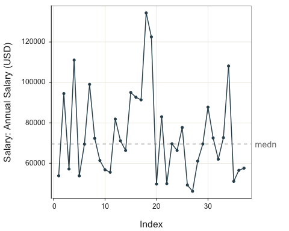

```
## >>> Suggestions
## Plot(Salary, run=TRUE, size=0)  # just line segments, no points
## Plot(Salary, run=TRUE, lwd=0)  # just points, no line segments
## Plot(Salary, run=TRUE, fill="on")  # default color fill
##
##      n   miss         mean           sd          min          mdn          max
##      37      0    73795.557    21799.533    46124.970    69547.600   134419.230
##
## ------------
## Run Analysis
## ------------
##
## Total number of runs: 21
## Total number of values that do not equal the median: 36
```

```r
Plot(Salary, run=TRUE)
```

The default run chart displays the plotted points in a small size with connecting line segments. Change the size of the points with the parameter `size`, here set to zero to remove the points entirely. Fill the area under the line segments with the parameter `area_fill`, here set to the default `on` but can express any color. Remove the center line with the parameter `center_line` set to `off`.

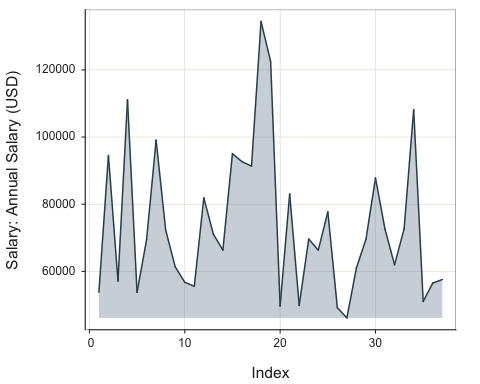

```
## >>> Suggestions
## Plot(Salary, size=0, run=TRUE, area_fill="on", center_line="off", lwd=0, fill="on")  # just area
##
##      n   miss         mean           sd          min          mdn          max
##      37      0    73795.557    21799.533    46124.970    69547.600   134419.230
##
## ------------
## Run Analysis
## ------------
##
## Total number of runs: 21
## Total number of values that do not equal the median: 36
```

```r
Plot(Salary, run=TRUE, size=0, area_fill="on", center_line="off")
```

## Time Series Chart

`Plot()` can plot a time series from three different forms of the data:

- long-form
- wide-form
- time-series object

`Plot()` can also similarly plot a run chart in which it generates the index values sequentially ordered. A time series requires two variables, the time/date and each corresponding measured value to be plotted.

### Long-Format Data

Read time series data of stock *Price* for three companies: Apple, IBM, and Intel. The data table is in long form, part of **lessR**.

```r
d <- Read("StockPrice")
```

```
##
## >>> Suggestions
## Recommended binary format for data files: feather
##   Create with Write(d, "your_file", format="feather")
## More details about your data, Enter:  details()  for d, or  details(name)
##
## Data Types
## ------------------------------------------------------------
## character: Non-numeric data values
## Date: Date with year, month and day
## double: Numeric data values with decimal digits
## ------------------------------------------------------------
##
##     Variable                  Missing  Unique
##         Name     Type  Values  Values  Values   First and last values
## ------------------------------------------------------------------------------------------
##  1     Month      Date   1419       0     473   1985-01-01 ... 2024-05-01
##  2   Company character   1419       0       3   Apple  Apple ... Intel  Intel
##  3     Price    double   1419       0    1400   0.100055  0.085392 ... 30.346739  30.555891
##  4    Volume    double   1419       0    1419   6366416000 ... 229147100
## ------------------------------------------------------------------------------------------
```

```r
d[1:5,]
```

```
##        Month Company    Price     Volume
## 1 1985-01-01   Apple 0.100055 6366416000
## 2 1985-02-01   Apple 0.085392 4733388800
## 3 1985-03-01   Apple 0.076335 4615587200
## 4 1985-04-01   Apple 0.073316 2868028800
## 5 1985-05-01   Apple 0.059947 4639129600
```

If the $x$-variable is a four-digit integer year, then the resulting plot will be of points without connecting line segments. To covert a four-digit integer year, here named Year, to type `Date`, do the following transformation:

```
d$Year_date <- as.Date(ISOdate(d$Year, 1, 1))
```

Or, to plot as a time series, add `segments=TRUE` to the `Plot()` statement. To plot only the connecting line segments but not the points, also add `size=0`.

```
##
## filter:  (Company == "Apple")
## -----
## Rows of data before filtering:  1419
## Rows of data after filtering:   473
```

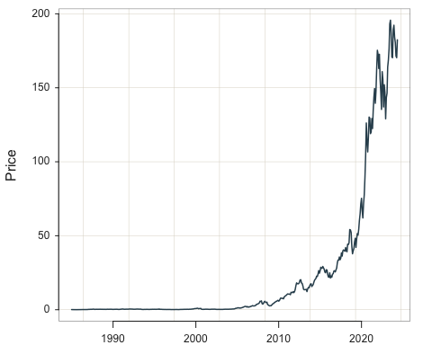

```
## --- Pearson's product-moment correlation ---
##
## Number of paired values with neither missing, n = 473
## Sample Correlation of Month and Price: r = 0.690
##
## Hypothesis Test of 0 Correlation:  t = 20.694,  df = 471,  p-value = 0.000
## 95% Confidence Interval for Correlation:  0.640 to 0.735
##
```

```r
Plot(Month, Price, filter=(Company=="Apple"))
```

Here, add the default fill color by setting the `area_fill` parameter to `"on"`. Can also specify a custom color.

```
##
## filter:  (Company == "Apple")
## -----
## Rows of data before filtering:  1419
## Rows of data after filtering:   473
```

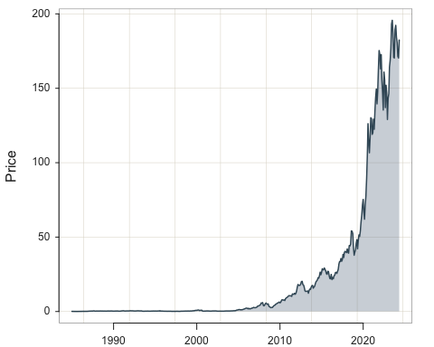

```
## --- Pearson's product-moment correlation ---
##
## Number of paired values with neither missing, n = 473
## Sample Correlation of Month and Price: r = 0.690
##
## Hypothesis Test of 0 Correlation:  t = 20.694,  df = 471,  p-value = 0.000
## 95% Confidence Interval for Correlation:  0.640 to 0.735
##
```

```r
Plot(Month, Price, filter=(Company=="Apple"), area_fill="on")
```

With the `by` parameter, plot all three companies on the same panel.

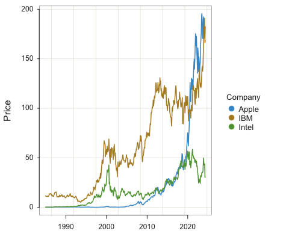

```r
Plot(Month, Price, by=Company)
```

Stack the plots by setting the parameter `stack` to `TRUE`.

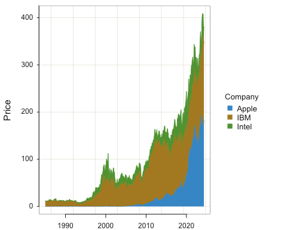

```r
Plot(Month, Price, by=Company, stack=TRUE)
```

With the `by1` parameter, plot all three companies on the different panels, a Trellis plot.

```
## [Trellis graphics from Deepayan Sarkar's lattice package]
```

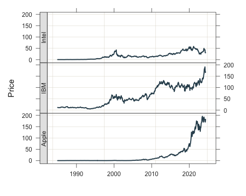

```r
Plot(Month, Price, by1=Company)
```

Do the Trellis plot with some color. Learn more about customizing visualizations in the vignette `utlities`.

```
## [Trellis graphics from Deepayan Sarkar's lattice package]
```

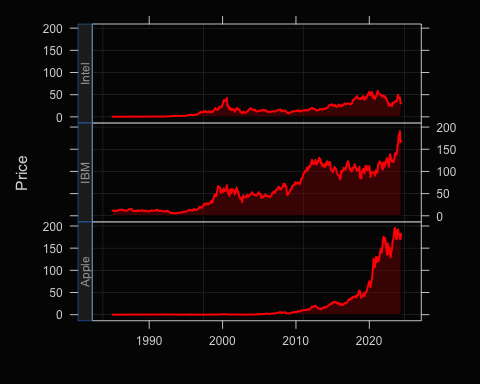

```r
style(sub_theme="black", window_fill="gray10")
Plot(Month, Price, by1=Company, n_col=1, fill="darkred", color="red", trans=.55)
```

Return to the default style, then turn off text output for subsequent analyses.

```r
style()
```

```
## theme set to "colors"
```

```r
style(quiet=TRUE)
```

Set a baseline of 25 with the `area_origin` parameter for a Trellis plot, with default fill color.

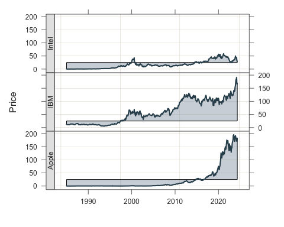

```r
Plot(Month, Price, by1=Company, xlab="", area_fill="on", area_origin=25)
```

Change the aspect ratio with the `aspect` parameter defined as height divided by width.

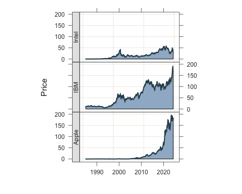

```r
Plot(Month, Price, by1=Company, aspect=.5, area_fill="slategray3")
```

Stack the three time series, fill under each curve with a version of the **lessR** sequential range `"emeralds"`.

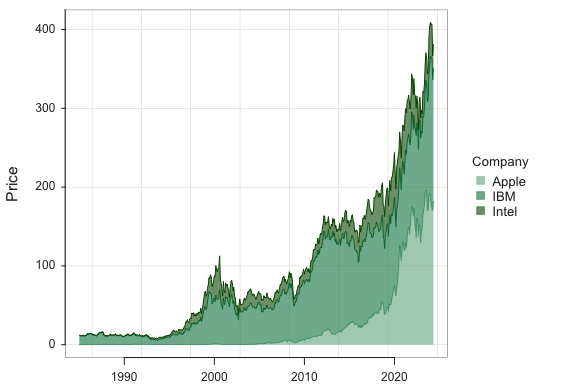

```r
Plot(Month, Price, by=Company, trans=0.4, stack=TRUE, area_fill="emeralds")
```

### Wide-Format Data

`Plot()` also reads wide-format data. We have no available wide form time data with **lessR**, so first convert the long form as read to the wide form. In the wide form, the three companies each have their own column of data, repeated for each date. Use the **lessR** function `reshape_wide()` to do the conversion.

```r
dw <- reshape_wide(d, group="Company", response="Price", ID="Month")
head(dw)
```

```
##        Month    Apple      IBM    Intel
## 1 1985-01-01 0.100055 11.71846 0.359457
## 2 1985-02-01 0.085392 11.51437 0.327310
## 3 1985-03-01 0.076335 11.00154 0.324388
## 4 1985-04-01 0.073316 10.95822 0.321466
## 5 1985-05-01 0.059947 11.14231 0.308315
## 6 1985-06-01 0.062103 10.81489 0.303932
```

Now the analysis, which repeats a previous analysis, but with wide-form data. Because the data frame is not the default *d*, explicitly indicate with the `data` parameter.

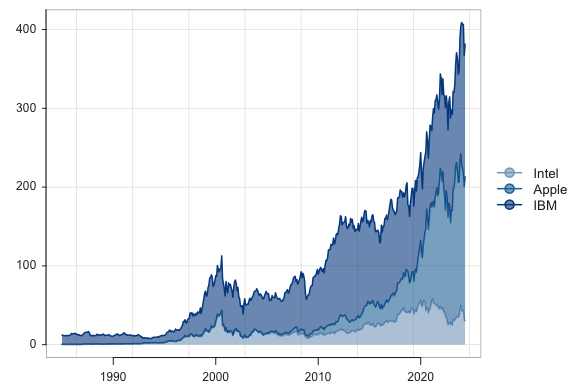

```r
Plot(Month, c(Intel, Apple, IBM), area_fill="blues", stack=TRUE, trans=.4, data=dw)
```

### Time-Series Object Data

Can also plot directly from an R time series object, created with the base R `ts()` function.

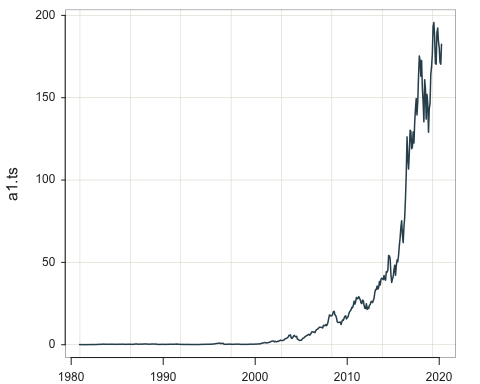

```r
a1.ts <- ts(dw$Apple, frequency=12, start=c(1980, 12))
Plot(a1.ts)
```

With `style()` many themes can be selected, such as `"lightbronze"`, `"dodgerblue"`, `"darkred"`, and `"gray"` for gray scale. When no `theme` or any other parameter value is specified, return to the default theme, `colors`.

```r
style()
```

## Annotation

The annotations in the following visualization consist of the text field “iPhone” with an arrowhead that points to the time that the first iPhone became available. With **lessR**, list each component of the annotation as a vector for add. Any value listed that is not a keyword such as “rect” or “arrow” is interpreted as a text field. Then, in order of their occurrence in the vector for add, list the needed coordinates for the objects. To place the text field “iPhone” requires one coordinate, `<x1,y1>`. To place an “arrow” requires two coordinates, `<x1,y1>` and `<x2,y2>`. For example, the second element of the `y1` vector is the `y1` value for the “arrow”. The text field does not require a second coordinate, so specify `x2` and `y2` as single elements instead of vectors.

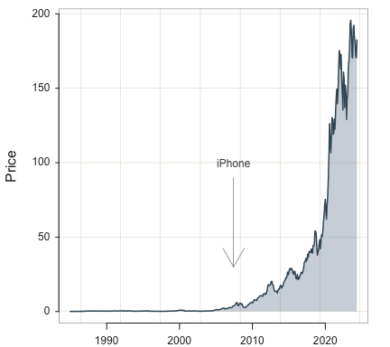

```r
x <- as.Date("2007-06-01")
Plot(Month, Price, filter=(Company == "Apple"), fill="on",
            add=c("iPhone", "arrow"),
            x1=c(x,x), y1=c(100,90), x2=x, y2=30)
```

## Full Manual

Use the base R `help()` function to view the full manual for `Plot()`. Simply enter a question mark followed by the name of the function.

```
?Plot
```

## More

More on Scatterplots, Time Series plots, and other visualizations from **lessR** and other packages such as **ggplot2** at:

Gerbing, D., *R Visualizations: Derive Meaning from Data*, CRC Press, May, 2020, ISBN 978-1138599635.